# Portfolio Exercise 2.1, Methods 3, 2021, autumn semester

### 2) Now fit a multilevel model that models a unique “slope” for *pas* for each *subject* with the interaction between *pas* and *task* and their main effects being modelled

```r
model_3.1 <- lme4::glmer(count ~ pas * task + (1 + pas | subject),
                   data = data.count,
                   family = 'poisson',
                   control = glmerControl(optimizer = "bobyqa")) # optimizer is used due to convergence issues
```

**i. which family should be used?**

A Poisson-distribution should be used as we are investigating count data.

**ii. why is a slope for *pas* not really being modeled?**

*pas* is encoded as factor, i.e. a categorical variable, meaning that it is assumed not to lie along a continuum (the differences between the levels are not incremental) and therefore has to be analyzed separately per level.

**iii. if you get a convergence error, try another algorithm (the default is the *Nelder_Mead*) - try (*bobyqa*) for which the `dfoptim` package is needed. In `glmer`, you can add the following for the `control` argument: `glmerControl(optimizer="bobyqa")` (if you are interested, also have a look at the function `allFit`)**

**iv. when you have a converging fit - fit a model with only the main effects of *pas* and *task*. Compare this with the model that also includes the interaction**

```r
model_3.2 <- lme4::glmer(count ~ pas + task + (1 + pas | subject),
                    data = data.count,
                    family = 'poisson',
                    control = glmerControl(optimizer = "bobyqa"))
```

**v. indicate which of the two models, you would choose and why**

```r
# AIC comparison:
AIC(model_3.1, model_3.2)
```

```
##           df      AIC
## model_3.1 22 3148.441
## model_3.2 16 3398.549
```

```r
# Residual variance:
c(sum(residuals(model_3.1)^2),
  sum(residuals(model_3.2)^2)
)
```

```
## [1] 699.4866 962.4628
```

```r
# Residual standard deviation:
c(sigma(model_3.1),
  sigma(model_3.2)
)
```

```
## [1] 1 1
```

**vi. based on your chosen model - write a short report on what this says about the distribution of ratings as dependent on *pas* and *task***

```r
summary(model_3.1)
```

```
## Generalized linear mixed model fit by maximum likelihood (Laplace
##   Approximation) [glmerMod]
##  Family: poisson  ( log )
## Formula: count ~ pas * task + (1 + pas | subject)
##    Data: data.count
## Control: glmerControl(optimizer = "bobyqa")
##
##      AIC      BIC   logLik deviance df.resid
##   3148.4   3232.7  -1552.2   3104.4      318
##
## Scaled residuals:
##     Min      1Q  Median      3Q     Max
## -4.3871 -0.7853 -0.0469  0.7550  6.5438
##
## Random effects:
##  Groups  Name        Variance Std.Dev. Corr
##  subject (Intercept) 0.3324   0.5765
##          pas2        0.3803   0.6167   -0.75
##          pas3        1.1960   1.0936   -0.84  0.63
##          pas4        2.3736   1.5407   -0.86  0.42  0.72
## Number of obs: 340, groups:  subject, 29
##
## Fixed effects:
##                     Estimate Std. Error z value Pr(>|z|)
## (Intercept)          4.03570    0.10976  36.770  < 2e-16 ***
## pas2                -0.02378    0.11963  -0.199 0.842456
## pas3                -0.51365    0.20717  -2.479 0.013164 *
## pas4                -0.77292    0.29075  -2.658 0.007851 **
## taskquadruplet       0.11490    0.03127   3.674 0.000239 ***
## tasksingles         -0.23095    0.03418  -6.756 1.42e-11 ***
## pas2:taskquadruplet -0.11376    0.04605  -2.470 0.013508 *
## pas3:taskquadruplet -0.20902    0.05287  -3.954 7.69e-05 ***
## pas4:taskquadruplet -0.21500    0.05230  -4.111 3.94e-05 ***
## pas2:tasksingles     0.19536    0.04830   4.045 5.23e-05 ***
## pas3:tasksingles     0.24299    0.05369   4.526 6.02e-06 ***
## pas4:tasksingles     0.56346    0.05101  11.045  < 2e-16 ***
## ---
## Signif. codes:  0 '***' 0.001 '**' 0.01 '*' 0.05 '.' 0.1 ' ' 1
##
## Correlation of Fixed Effects:
```

[output cut: 9 more lines]

```
## ps2:tsksngl  0.098 -0.188 -0.052 -0.037 -0.342 -0.708  0.490    0.203
## ps3:tsksngl  0.088 -0.080 -0.124 -0.033 -0.308 -0.637  0.209    0.486
## ps4:tsksngl  0.092 -0.085 -0.049 -0.091 -0.324 -0.670  0.220    0.192
##             ps4:tskq ps2:tsks ps3:tsks
## pas2
## pas3
## pas4
## taskqudrplt
## tasksingles
## ps2:tskqdrp
## ps3:tskqdrp
## ps4:tskqdrp
## ps2:tsksngl  0.205
## ps3:tsksngl  0.184    0.451
## ps4:tsksngl  0.507    0.474    0.427
```

```r
#When you want to interpret the output of a Poisson regression, you have to take the exp() of output. In order to not have a mental breakdown, let's collect it into a handy table:
normal <- fixef(model_3.1)
exponentiated <- exp(fixef(model_3.1))
poisson <- as.data.frame(cbind(normal, exponentiated))

#If the value is negative, it implies a decrease, and the exponentiated value has to be subtracted from 1
poisson$corrected <- ifelse((poisson$normal < 0), 1 - poisson$exponentiated, poisson$exponentiated)
poisson$direction <- ifelse((poisson$normal < 0), "decrease", "increase")

poisson
```

```
##                          normal exponentiated   corrected direction
## (Intercept)          4.03570123    56.5825836 56.58258362  increase
## pas2                -0.02377598     0.9765044  0.02349556  decrease
## pas3                -0.51364811     0.5983089  0.40169110  decrease
## pas4                -0.77292326     0.4616615  0.53833846  decrease
## taskquadruplet       0.11490066     1.1217620  1.12176199  increase
## tasksingles         -0.23094567     0.7937826  0.20621741  decrease
## pas2:taskquadruplet -0.11375513     0.8924765  0.10752353  decrease
## pas3:taskquadruplet -0.20901514     0.8113830  0.18861705  decrease
## pas4:taskquadruplet -0.21500491     0.8065375  0.19346252  decrease
## pas2:tasksingles     0.19536301     1.2157522  1.21575224  increase
## pas3:tasksingles     0.24299389     1.2750608  1.27506084  increase
## pas4:tasksingles     0.56346179     1.7567435  1.75674346  increase
```

An increase in probability for so rating a trial is shown for all interactions moving along the PAS scale for “singles” tasks (~21.57%, ~27.51% and ~75.67%, respectively), while a decrease can be noted for “quadruplets” tasks (~10.75%, ~18.85%, ~19.35% respectively).

All main and interaction effects are significant, p < .05, with the exception of moving from PAS rating 1 to PAS rating 2.

**vii. include a plot that shows the estimated amount of ratings for four subjects of your choosing.**

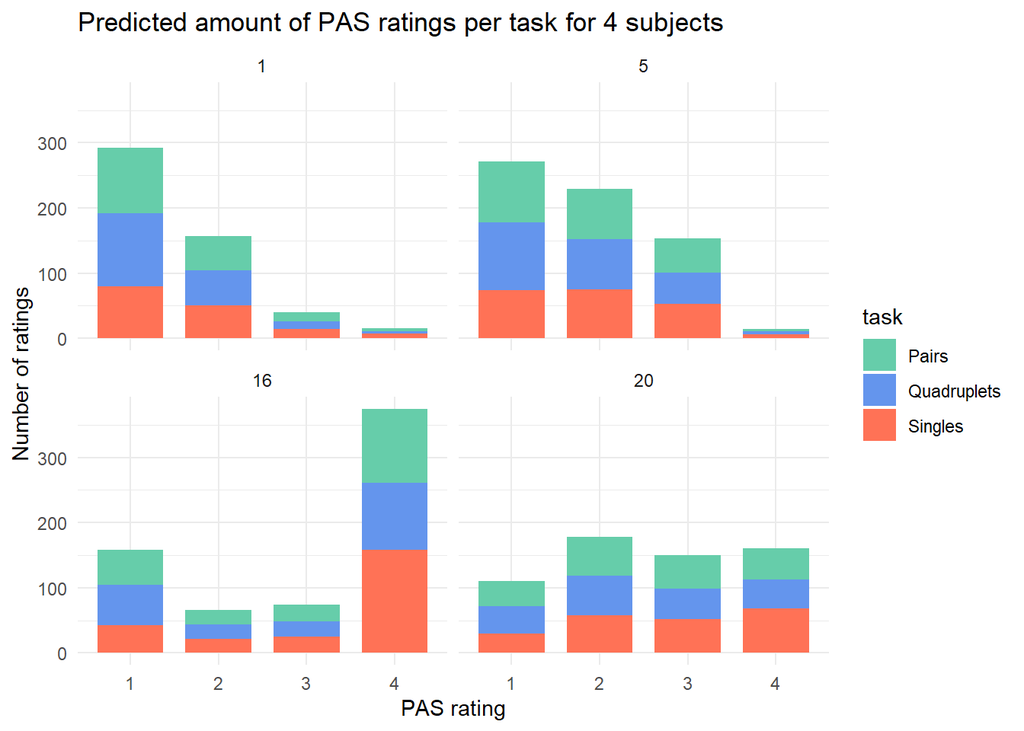

```r
# When making predictions from a regression model, we can make either in-sample or out-of-sample predictions.
# When making in-sample predictions, we basically obtain the predicted values for the y axis based on the existing values on the x axis; i.e. the value on y if there was no error. These are the fitted values.
# Since we are trying to estimate ratings for subjects already in the dataset, we make in-sample predictions.

# Get the subjects
subject1 = data.count %>%
  filter(subject == '1')
subject5 = data.count %>%
  filter(subject == '5')
subject16 = data.count %>%
  filter(subject == '16')
subject20 = data.count %>%
  filter(subject == '20')

# Predict & exponentiate for them
pred1 = predict(model_3.1, newdata = subject1)
subject1$prediction = expm1(pred1)
pred5 = predict(model_3.1, newdata = subject5)
subject5$prediction = expm1(pred5)
pred16 = predict(model_3.1, newdata = subject16)
subject16$prediction = expm1(pred16)
pred20 = predict(model_3.1, newdata = subject20)
subject20$prediction = expm1(pred20)

# Get the subjects into one df
df_3.1 = rbind(subject1, subject5, subject16, subject20)

# Plot
ggplot(data = df_3.1, aes(x = pas, y = prediction, fill = task)) +
  geom_col(width = 0.75) +
  facet_wrap(~subject) +
  labs(title = "Predicted amount of PAS ratings per task for 4 subjects", x = "PAS rating", y = "Number of ratings") +
  scale_fill_manual(labels = c("Pairs", "Quadruplets", "Singles"), values = c("aquamarine3", "cornflowerblue", "coral1")) +
  guides(color = guide_legend("Task")) +
  theme_minimal()
```

### 3) Finally, fit a multilevel model that models *correct* as dependent on *task* with a unique intercept for each *subject*

No dataset was specified for this exercise, but it made most sense to us to use the data for the experimental trials.

```r
model_3.3a <- lme4::glmer(correct ~ task + (1 | subject),
                          family = 'binomial',
                          data = exp)
summary(model_3.3a)$coefficients
```

```
##                   Estimate Std. Error   z value     Pr(>|z|)
## (Intercept)     1.11895699 0.11765673  9.510353 1.900168e-21
## taskquadruplet -0.07495728 0.05080445 -1.475408 1.401029e-01
## tasksingles     0.16603081 0.05217255  3.182340 1.460900e-03
```

**i. does *task* explain performance?**

*task* appears to significantly modulate performance when it is *singles* compared to *doubles* (β = 0.16603, SE = 0.05217, p < .05), but not when it is *quadruplets* compared to *doubles*.

**ii. add *pas* as a main effect on top of *task* - what are the consequences of that?**

```r
model_3.3b <- lme4::glmer(correct ~ task + pas + (1 | subject),
                          family = 'binomial',
                          data = exp)
summary(model_3.3b)$coefficients
```

```
##                   Estimate Std. Error    z value      Pr(>|z|)
## (Intercept)     0.14963454 0.10251803  1.4595923  1.444021e-01
## taskquadruplet -0.02659258 0.05367436 -0.4954428  6.202876e-01
## tasksingles    -0.03641710 0.05568565 -0.6539765  5.131270e-01
## pas2            0.88735443 0.05413990 16.3900280  2.253407e-60
## pas3            1.87054268 0.07481891 25.0009332 5.972201e-138
## pas4            2.88684584 0.10239532 28.1931430 7.096573e-175
```

When taking both *pas* and *task* as predictor variables, *task* no longer significantly explains performance, but *pas* does (PAS 2: β = 0.88735, SE = 0.05414, p < .001; PAS 3: β = 1.87054, SE = 0.07482, p < .001; PAS 4: β = 2.88685, SE = 0.10240, p < .001).

**iii. now fit a multilevel model that models *correct* as dependent on *pas* with a unique intercept for each *subject***

```r
model_3.3c <- lme4::glmer(correct ~ pas + (1 | subject), family = 'binomial', data = exp)
summary(model_3.3c)$coefficients
```

```
##              Estimate Std. Error   z value      Pr(>|z|)
## (Intercept) 0.1301357 0.09789466  1.329344  1.837346e-01
## pas2        0.8863758 0.05406860 16.393542  2.126814e-60
## pas3        1.8689071 0.07461743 25.046523 1.904981e-138
## pas4        2.8819760 0.10168518 28.342144 1.046071e-176
```

*pas* significantly explains performance, (PAS 2: β = 0.88638, SE = 0.05407, p < .001; PAS 3: β = 1.86891, SE = 0.07462, p < .001; PAS 4: β = 2.88198, SE = 0.10169, p < .001).

**iv. finally, fit a model that models the interaction between *task* and *pas* and their main effects**

```r
model_3.3d <- lme4::glmer(correct ~ task * pas + (1 | subject), family = 'binomial', data = exp)
summary(model_3.3d)
```

```
## Generalized linear mixed model fit by maximum likelihood (Laplace
##   Approximation) [glmerMod]
##  Family: binomial  ( logit )
## Formula: correct ~ task * pas + (1 | subject)
##    Data: exp
##
##      AIC      BIC   logLik deviance df.resid
##  12265.8  12362.4  -6119.9  12239.8    12515
##
## Scaled residuals:
##     Min      1Q  Median      3Q     Max
## -6.4527 -0.7529  0.3231  0.6026  1.6685
##
## Random effects:
##  Groups  Name        Variance Std.Dev.
##  subject (Intercept) 0.2403   0.4902
## Number of obs: 12528, groups:  subject, 29
##
## Fixed effects:
##                     Estimate Std. Error z value Pr(>|z|)
## (Intercept)          0.14960    0.10797   1.386    0.166
## taskquadruplet       0.03068    0.07760   0.395    0.693
## tasksingles         -0.11076    0.08400  -1.319    0.187
## pas2                 0.91504    0.08891  10.292   <2e-16 ***
## pas3                 1.82975    0.12090  15.135   <2e-16 ***
## pas4                 2.83307    0.17329  16.349   <2e-16 ***
## taskquadruplet:pas2 -0.11916    0.12079  -0.987    0.324
## tasksingles:pas2     0.05846    0.12719   0.460    0.646
## taskquadruplet:pas3 -0.06632    0.16768  -0.396    0.692
## tasksingles:pas3     0.20714    0.17125   1.210    0.226
## taskquadruplet:pas4 -0.17375    0.23482  -0.740    0.459
## tasksingles:pas4     0.28171    0.22689   1.242    0.214
## ---
## Signif. codes:  0 '***' 0.001 '**' 0.01 '*' 0.05 '.' 0.1 ' ' 1
##
## Correlation of Fixed Effects:
##             (Intr) tskqdr tsksng pas2   pas3   pas4   tskq:2 tsks:2 tskq:3
## taskqudrplt -0.370
## tasksingles -0.340  0.474
## pas2        -0.350  0.451  0.414
## pas3        -0.269  0.333  0.304  0.335
## pas4        -0.197  0.230  0.205  0.227  0.189
## tskqdrplt:2  0.237 -0.644 -0.304 -0.695 -0.212 -0.147
## tsksngls:p2  0.232 -0.313 -0.662 -0.670 -0.213 -0.144  0.484
## tskqdrplt:3  0.171 -0.464 -0.221 -0.210 -0.680 -0.104  0.299  0.146
## tsksngls:p3  0.170 -0.233 -0.492 -0.204 -0.671 -0.107  0.149  0.327  0.481
## tskqdrplt:4  0.121 -0.331 -0.156 -0.148 -0.109 -0.693  0.212  0.102  0.152
## tsksngls:p4  0.126 -0.175 -0.369 -0.150 -0.109 -0.719  0.112  0.243  0.082
##             tsks:3 tskq:4
## taskqudrplt
## tasksingles
## pas2
## pas3
## pas4
## tskqdrplt:2
## tsksngls:p2
## tskqdrplt:3
## tsksngls:p3
## tskqdrplt:4  0.076
## tsksngls:p4  0.181  0.530
```

It still only seems to be *pas* that significantly modulates accuracy, (PAS 2: β = 0.91504, SE = 0.08891, p < .001; PAS 3: β = 1.82975, SE = 0.12090, p < .001; PAS 4: β = 2.83307, SE = 0.17329, p < .001)

**v. describe in your words which model is the best in explaining the variance in accuracy**

```r
#Residual variance:
c(sum(residuals(model_3.3a)^2),
  sum(residuals(model_3.3b)^2),
  sum(residuals(model_3.3c)^2),
  sum(residuals(model_3.3d)^2)
)
```

```
## [1] 13503.97 12137.57 12138.07 12130.75
```

```r
#AIC
AIC(model_3.3a, model_3.3b, model_3.3c, model_3.3d)
```

```
##            df      AIC
## model_3.3a  4 13636.29
## model_3.3b  7 12260.41
## model_3.3c  5 12256.88
## model_3.3d 13 12265.77
```